# 5. Plotting

Diego Uchendu

10/05/2020

#5.1 Basic plotting routines

Very simple scatter plot

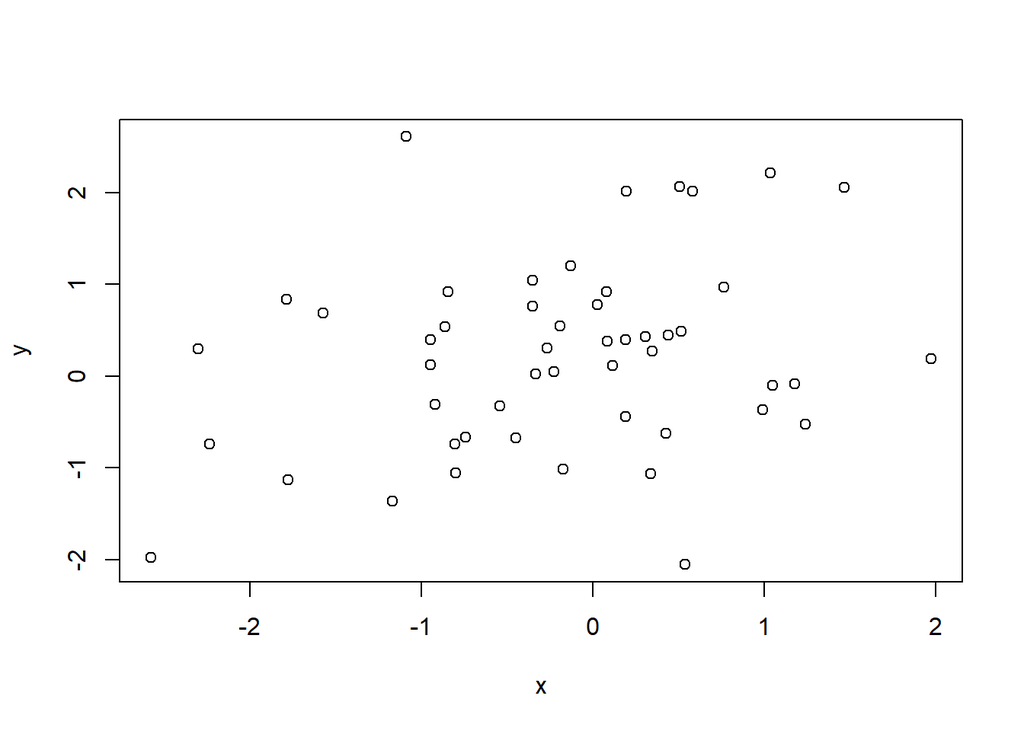

```r
n <- 50 #number of points to plot
x <- rnorm(n)#random density distribution function for normal distribution
y <- rnorm(n) #independent y coordinates
plot(x,y, xlab = "x", ylab="y")# xlab and ylab define axis labels
```

#a still simple data set

```r
n <- 50 #number of points to plot
x <- rnorm(n,10,2)# mean=10 std=2
y <- 2*x + rnorm(n,0,sqrt(x)) #linearly dependent y coordinates with heteroscedastic errors

?par
```

```
## starting httpd help server ... done
```

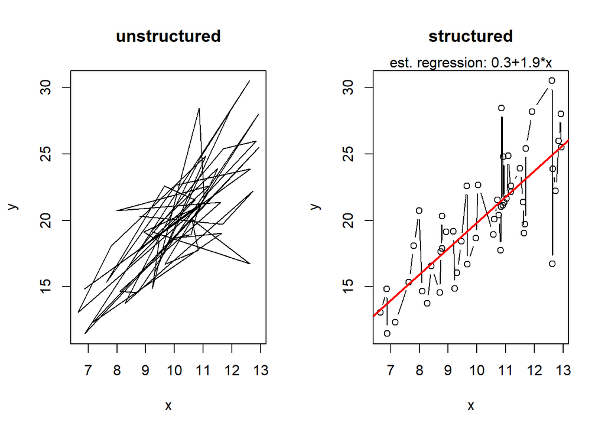

```r
par(mfrow =c(1,2))#set up a device with 2 plots

?plot
#"p" for points,"l" for lines, "b" for both,

plot(x,y, xlab ="x",ylab = "y", type = "l", main ="unstructured" ) # one can also plot lines and a title
#order arranges indexes according to there values ascending or descending order.
#x[order(x)]
plot(x[order(x)],y[order(x)],xlab = "x",ylab = "y",type = "b", main = "structured")# as well as points and lines
?lm#fitting linear regression models
lin.reg <-lm(y~x)
abline(lin.reg,col="red",lwd=2)# and plot the regression line
mtext(text = paste("est. regression: ", round(lin.reg$coefficients[1],1), "+", round(lin.reg$coefficients[2],1), "*x", sep = ""), side = 3) # and add the formula as text
```

## Exercise 1:

runif(n,min=-3,max=3) random uniform distribution

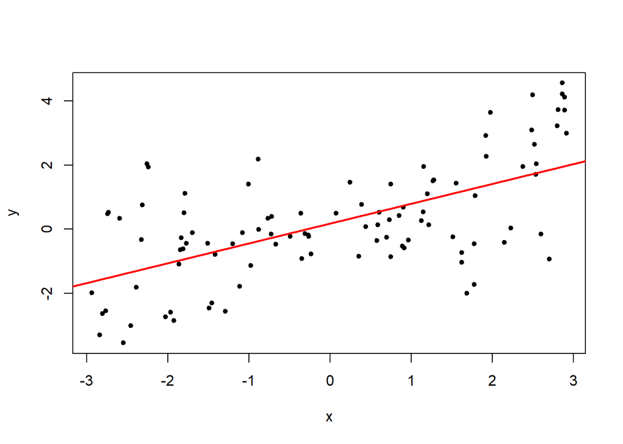

```r
n<- 100 #number of points to plot
x <- runif(n,min = -3, max=3) #100 x coordinates
y <- sin(3*x^2 -4)*x + 0.5* x + rnorm(n,mean = 0,sd=sqrt(.5))
?plot
#pch is plot character 0 to 20 is black color,
#pch 24 is triangle
plot(x[order(x)], y[order(x)], xlab = "x", ylab = "y", pch=20)
lin.reg <- lm(y~x) #fit a linear regression model
abline(lin.reg,col="red",lwd=2)# ... and plot the regression line
```

#plot a normal distribution

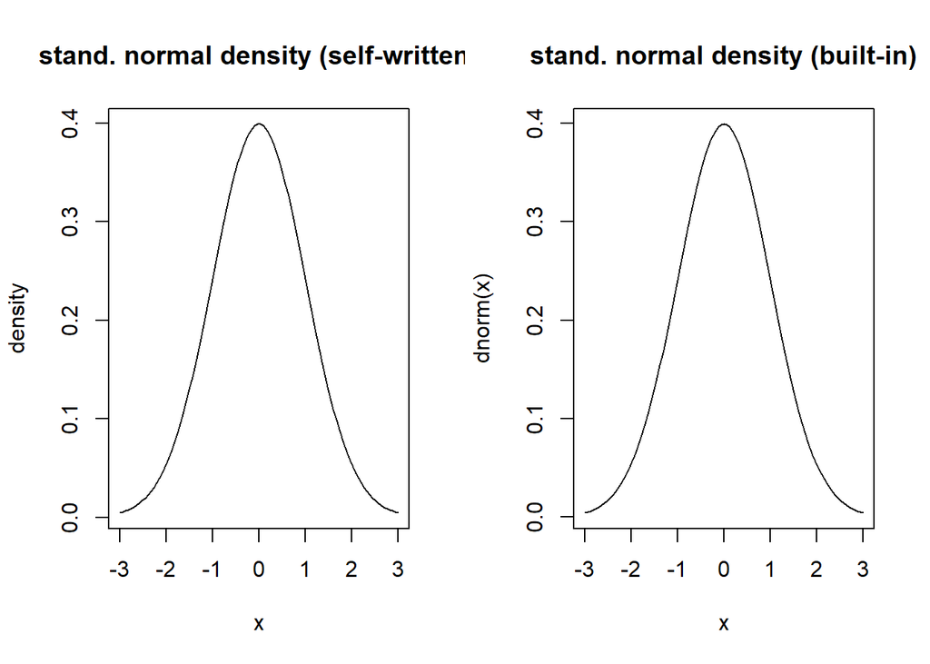

```r
man.norm <- function(x,mu=0,sigma=1)1/sqrt(2 * pi * sigma^2) * exp(-(x-mu)^2/2/sigma^2)     # density function normal distribution, self-written, default to standard normal
n <- 100
x <- seq(-3,3, length.out = n)# set plotting range (-3,3) and sample n equally spaced points
y <- man.norm(x) #calculate density at x-values
par(mfrow=c(1,2)) #set up a device with 2 plots
plot(x,y, xlab = "x", ylab = "density", type ="l", main = "stand. normal density (self-written)")
curve(dnorm, from = -3, to= 3, main="stand. normal density (built-in)")
```

##Exercise 2: Plot the EOQ model in an appropriate range. #EOQ function

```r
#cost function
cost_eoq_fun <- function(q, d, co, cl) {
  # returns total cost per period
  # d...demand
  # q...lot size
  # co...ordering cost
  # cl...stock holding cost
  ((1/2)*cl*q)+((d/q)*co)
}

#economic ordering quantity function
eoq_fun <- function(co, d, cl) {
  # return optimal lot size
  # d...demand
  # co...ordering cost
  # cl...stock holding cost
  sqrt((2*co*d)/cl)
}
```

#plotting

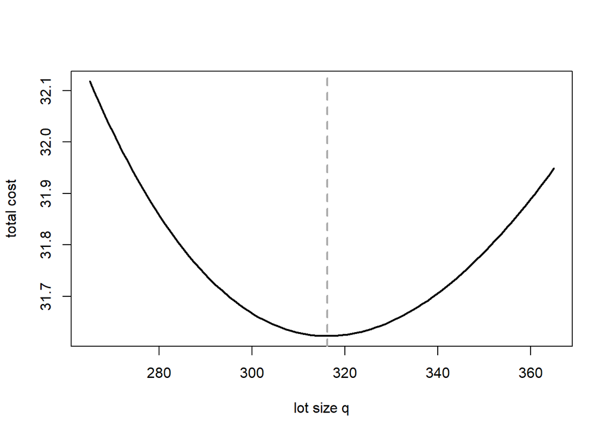

```
## integer(0)
```

```r
q.vec<- seq(265, 365, length.out = 100) #quantity vector setting plotting range for x axis
y.vec <- cost_eoq_fun(q=q.vec,d=100, cl=.1,co= 50)#the  EOQ function


#abline adds 1 or more straight lines on the current plot
?plot.new()

#line type (lty) can be specified using either text (“blank”, “solid”, “dashed”, “dotted”, “dotdash”, “longdash”, “twodash”) or number (0, 1, 2, 3, 4, 5, 6). Note that lty = “solid” is identical to lty=1.

#lwd is line width
plot(q.vec, y.vec, xlab = "lot size q", ylab = "total cost", type = "l",lwd=2)+ abline(v= eoq_fun(d=100, cl=.1, co=50), col="darkgrey",lwd=2,lty=2)
```

In the above plot EOQ is at the grey line. ##Exercise 3: Plot the newsvendor model in an appropriate range The total cost in the normal newsvendor model is given by $Z(q)= (c_u + c_o)\times σ \times(φ(q')+q'\times Φ (q'))-c_u \times(q-U)$ with $q' =\frac{(q-μ)}σ$

dnorm= density normal distribution pnorm= normal distribution function

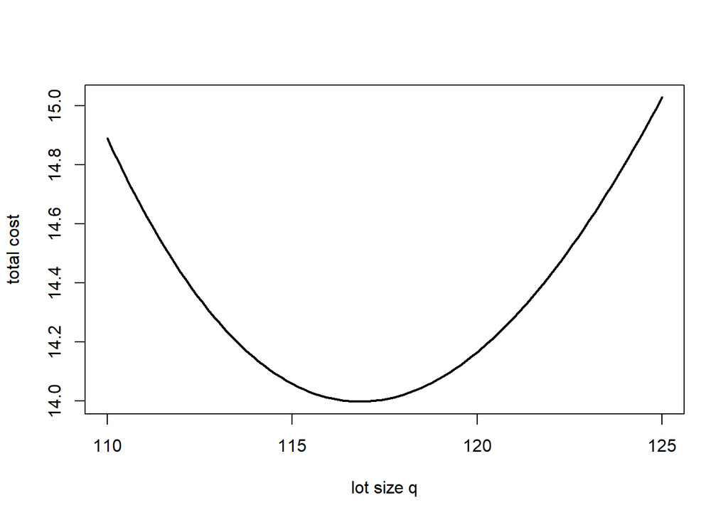

```r
newsven_obj_fun <- function(x, cu,co,mu,sigma){
  q.prime <- (x-mu)/sigma
         (cu + co) * sigma * (dnorm(q.prime) + q.prime * pnorm(q.prime)) - cu * sigma * q.prime

}
q.vec <- seq(110, 125, length.out = 100) # x axis
cost.vec <- newsven_obj_fun(x=q.vec, mu = 100, cu=2, co= 0.5, sigma = 20) #yaxis

plot(q.vec, cost.vec, xlab ="lot size q", ylab = "total cost", type = "l", lwd = 2)
```

#overlay different plots.

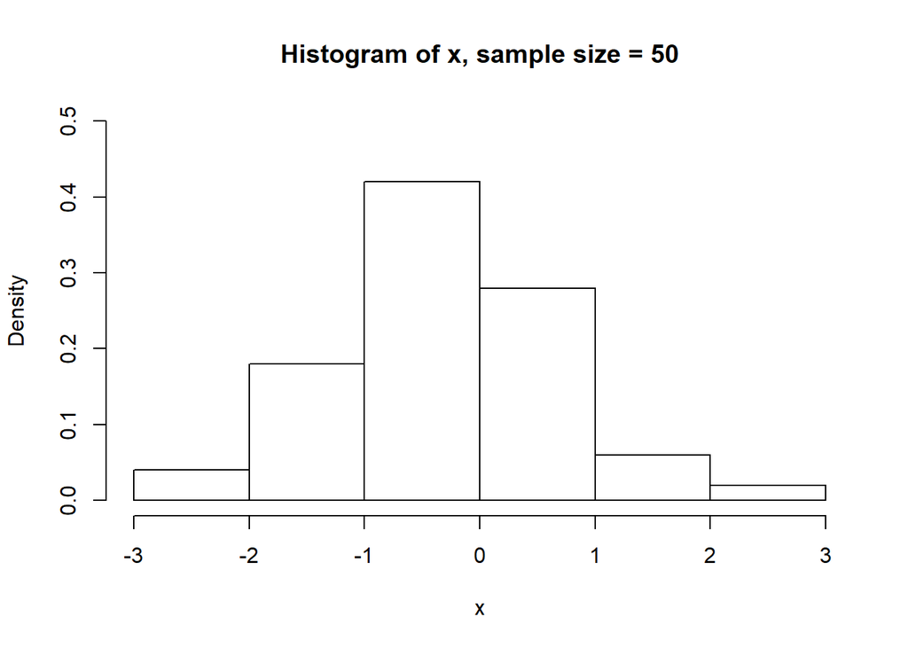

```r
#plot a normal distribution
n <- 50 #sample size
x <- rnorm(n) #sample from standard normal distribution
est.mu<- mean(x) #estimate mean
est.sd <- sd(x)  #estimate standard deviation

#plot histogram with density (default plots frequencies), specify plot range explicitely
hist(x, freq = FALSE,ylim = c(0,0.5),xlim = c(-3,3),main= paste("Histogram of x, sample size =", n) )
```

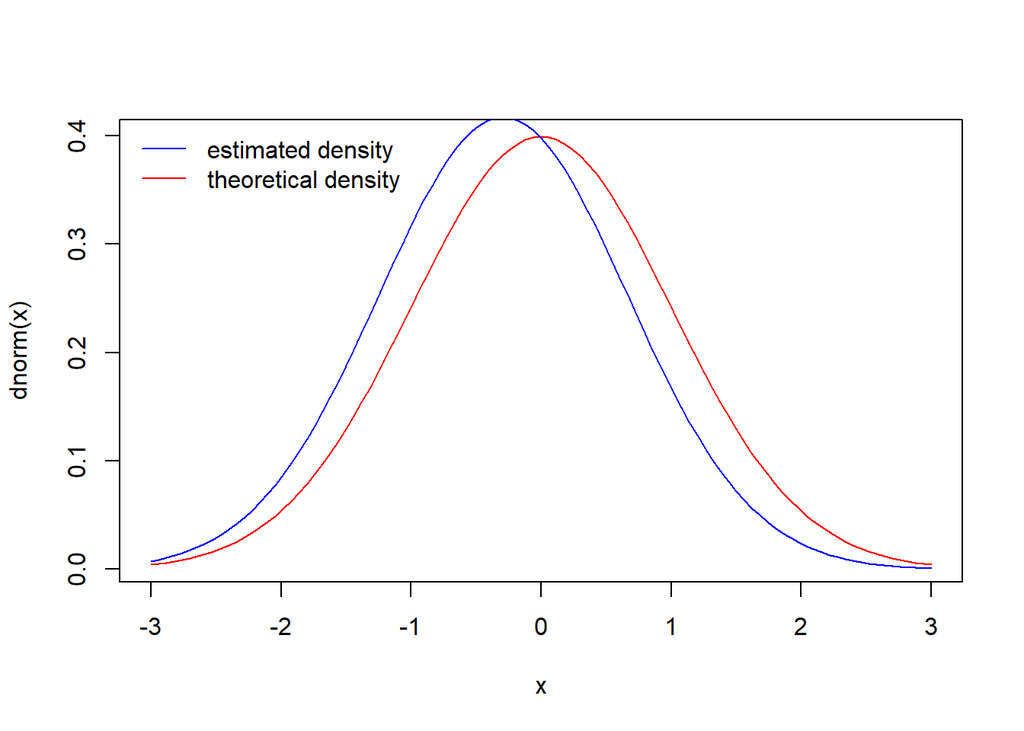

```r
#add theoretical density
#add=TRUE means add to already existing plot
curve(dnorm,from = -3, to = 3, col="red")

#add estimated density
{curve(1/sqrt(2 * pi * est.sd^2) * exp(-(x - est.mu)^2/2/est.sd^2), from = -3, to = 3, col = "blue", add = TRUE)
legend("topleft" , bty="n", col=c("blue","red"), lwd =c(1,1), legend = c("estimated density", "theoretical density"))}
```

```r
#topleft is position of the legend
```

##Exercise 4: Plot the EOQ model in an appropriate range and add holding cost function and ordering cost function in different colors. Add a legend to the plot.

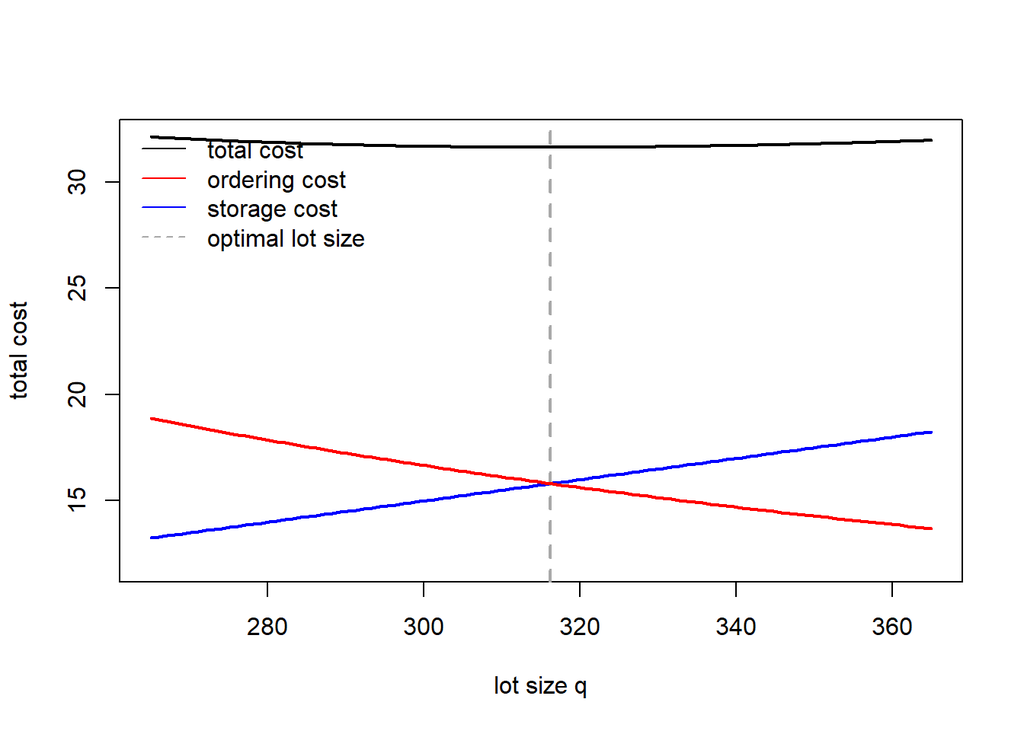

```r
q.vec <- seq(265, 365, length.out = 100)
y.vec <- cost_eoq_fun(q = q.vec , d = 100, cl = .1, co = 50)
{plot(q.vec, y.vec, xlab ="lot size q", ylab = "total cost", type = "l", lwd =2, ylim=c(12,max(y.vec)))+abline(v = eoq_fun(d = 100, cl = .1, co = 50), col="darkgrey", lwd=2, lty=2)+lines(x=q.vec, y=(1/2)*.1*q.vec, lwd=2, col="blue")+lines(x=q.vec, y=(100/q.vec)*50, lwd=2, col="red")
legend("topleft", lty = c(1,1,1,2), col = c("black","red","blue","darkgrey"), legend = c("total cost", "ordering cost", "storage cost", "optimal lot size"), bty="n" )}
```

#Exercise 5: Consider the in the joint economic lot size model. Supplier and customer face setup costs $(c_{set}^{sup},c_{set}^{cust})$ as well as stock-holding cost rates $(c_{sh}^{sup},c_{sh}^{cust})$ The demand rate of the customers is λ and production rate of the supplier is μ (with λ < μ). The cost functions of supplier and customer are: $C^{cust}(q) =\frac{λ}{q}\times c_{set}^{cust} + c_{sh}^{cust}\times \frac{q}{2}$ and $C^{supp}(q) =\frac{λ}{q}\times c_{set}^{sup} + c_{sh}^{sup}\times \frac{q}{2}\times \frac{λ}{μ}$ Plot the cost functions of supplier, customer, and the SC (i.e., total cost function) in different colors. Add a legend to the plot.

#which.min= index of the first minimum of numeric or logical vector

```r
jel_func <- function(q, c.supp.set, c.supp.sh, c.cust.set, c.cust.sh, lambda, mu){
  #costs in joint exonomic lot sizing model
  if(lambda > mu) stop("infeasible(lambda > mu)")#check feasibility
  c.cust <- lambda/q * c.cust.set + c.cust.sh * q/2
  c.supp <-  lambda/q * c.supp.set  + c.supp.sh * q/2 * lambda/mu
  c.sc <- c.supp + c.cust
  return(data.frame(cost.customer = c.cust, cost.supplier = c.supp, cost.sc = c.sc))
}

q.vec <- seq(50,200, length.out = 100)#x_axis
is.vector(q.vec)# this is a vector thats is columnwise also its an independent variable
```

```
## [1] TRUE
```

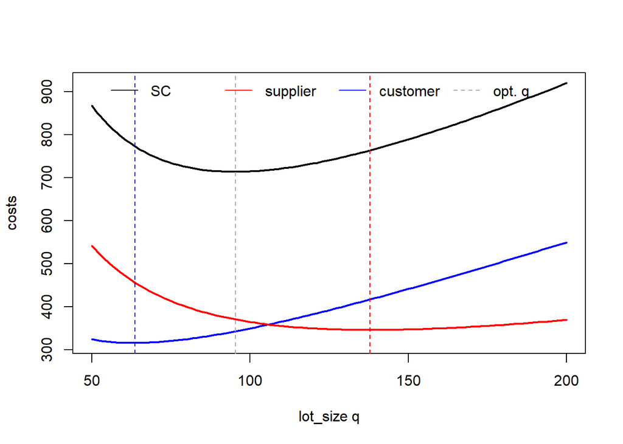

```r
y.df <- jel_func(q = q.vec, c.supp.set = 240, c.supp.sh = 4, c.cust.set = 100, c.cust.sh = 5, lambda = 100, mu = 160)

{plot(x=q.vec, y.df$cost.sc, xlab = "lot_size q",ylab = "costs",type = "l",lwd=2,ylim = range(y.df))+
  lines(x = q.vec, y = y.df$cost.customer, lwd = 2, col = "blue")+
  lines(x = q.vec, y = y.df$cost.supplier, lwd = 2, col = "red")+
  abline(v=q.vec[which.min(y.df$cost.customer)],col="blue",lwd=1, lty=2)+
  abline(v = q.vec[which.min(y.df$cost.supplier)], col = "red", lwd = 1, lty = 2)+
  abline(v = q.vec[which.min(y.df$cost.sc)], col = "darkgrey", lwd = 1, lty = 2)

legend("top", lty = c(1,1,1,2), col = c("black","red","blue","darkgrey"), legend = c("SC", "supplier", "customer", "opt. q"),bty = "n",horiz = T)}
```

Overlays are also useful when plots should be customized.

```r
#plot a normal distribution with annotation
n<- 1000 #set number
```